# Fourth Week: Hypothesis Testing

TIMSS Analysis

niloofar tarighat _ 94101448

2018-03-08 21:41:18

# تمرین سری چهارم: چقدر ریاضی بلدیم و چرا؟

لطفا مقاله زیر را مطالعه بفرمایید.

[چرایی رتبه ضعیف ایران در آزمون تیمز](https://goo.gl/gX8DZc)

> با استفاده از داده های ارزیابی تیمز ۲۰۱۵ ادعاهای زیر را مورد ارزیابی قراردهید. برای هر سوال علاوه بر استدلال آماری که در غالب آزمون فرض تعریف می شود از تصویرسازی مناسب باهر دو ابزار ggplot2 و highcharter استفاده نمایید. به دلخواه به هفت گزاره از موارد زیر پاسخ دهید.

۱. میران رضایت معلمان در پیشرفت تحصیلی دانش آموزان موثر است.

۲. والدینی که تحصیلات بیشتری دارند دارای فرزندان موفق تری می باشند.

```r
library(readr)
library(dplyr)
```

```r
library(highcharter)
library(ggplot2)
school_background = read_rds("/Users/macbook/Documents/university/term6/data analysis/bcg.rds") # school background
student_background= read_rds("/Users/macbook/Documents/university/term6/data analysis/bsg.rds") # student background
Teacher_background= read_rds("/Users/macbook/Documents/university/term6/data analysis/btm.rds") # Teacher background
student_result = read_rds("/Users/macbook/Documents/university/term6/data analysis/bsa.rds") # student result
student_teacher_linkage = read_rds("/Users/macbook/Documents/university/term6/data analysis/bst.rds") # student-teacher linkage
within_country= read_rds("/Users/macbook/Documents/university/term6/data analysis/bsr.rds") # within-country

tims=read_rds("/Users/macbook/Documents/university/term6/data analysis/tims.rds")

#H0: tahsilat valedein mostaghel az movafaghiat e danesh amoz ast
# ya tozi e nomre dar grouh ha ba tahsilat valedeine mokhtalef motefavet ast

student_background %>%
  select(idcntry,idschool,idstud,bsmmat01,bsmmat02,bsmmat03,bsmmat04,bsmmat05,
         bsbg07a,bsbg07b)->temp1

temp1$score <- apply(temp1[4:8], 1, mean,na.rm=T)
temp1$paredu <- apply(temp1[9:10], 1, mean,na.rm=T)


temp1 %>% select(paredu,score)->final

final %>% aov(score ~ paredu, data = .) -> fit
summary.aov(fit)
```

```
##                 Df    Sum Sq   Mean Sq F value Pr(>F)
## paredu           1 1.049e+08 104915634    9737 <2e-16 ***
## Residuals   273348 2.945e+09     10775
## ---
## Signif. codes:  0 '***' 0.001 '**' 0.01 '*' 0.05 '.' 0.1 ' ' 1
## 6780 observations deleted due to missingness
```

```r
#p value kuchik va F bozorg->daste ha motefavet and

# حال به کمک تی تست بین دو دسته با سواد و بی سواد تر نمرات فرزندان را مقایسه میکنیم

temp1 %>% filter(paredu==7 | paredu==1)->temp2
temp2 %>% select(paredu,score)->final2
hypo = t.test(score~paredu, data = final2)
hypo
```

```
##
##  Welch Two Sample t-test
##
## data:  score by paredu
## t = -105.47, df = 23174, p-value < 2.2e-16
## alternative hypothesis: true difference in means is not equal to 0
## 95 percent confidence interval:
##  -123.7748 -119.2582
## sample estimates:
## mean in group 1 mean in group 7
##        401.1093        522.6258
```

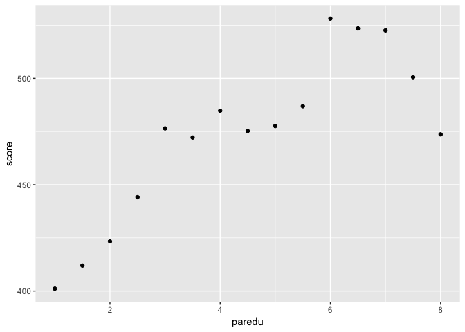

```r
# تی تست نشان میدهد که دانش آموزان با سطح تحصیلات بالاتر پدر و مادر دارای نمرات بهتری هستند

#visualization
#final %>% hchart(type = "line",hcaes(x =paredu, y =score),name="score_edu")
# be elat e hajm bala dataset kheili toolani mishavad rasm !!!!!!

final %>% group_by(paredu) %>% summarise(score=mean(score,na.rm = T))->stat
p=ggplot(data=stat,aes(x=paredu,y=score))
p+geom_point()
```

```r
#second visualizatioan
stat %>% hchart("column",hcaes(x=paredu,y=score))
```

[interactive chart not shown]

با تصویر سازی میبینیم که با افزایش سطح تحصیلات مادر و پدر به طور کلی نمره دانش آموز ارتقا پیدا میکند . البته در انتهای نمودار شاهد یک کاهش هستیم که احتمالا داده ی پرت است.

با تست آنوا میبینیم که دسته های مختلف از جهت سطح تحصیلات مادر و پدر دارای توزیع (میانگین ) های متفارتی هستند سپس با کمک تی تست روند نمره به ازای سطح تحصیلات را مشخص میکنیم.

۳. امکانات رفاهی در خانه موجب پیشرفت تحصیلی می گردد.

```r
#H0:دسته ها تفاوتی ندارند
student_background %>%
  select(idcntry,idschool,idstud,bsmmat01,bsmmat02,bsmmat03,bsmmat04,bsmmat05,bsdgher)->temp1
# 1: Many Resources; 2: Some Resources; 3: Few Resources

temp1$score <- apply(temp1[4:8], 1, mean,na.rm=T)
temp1 %>% aov(bsdgher~score,data=.)->fit
summary.aov(fit)
```

```
##                 Df Sum Sq Mean Sq F value Pr(>F)
## score            1  11884   11884   48161 <2e-16 ***
## Residuals   274774  67801       0
## ---
## Signif. codes:  0 '***' 0.001 '**' 0.01 '*' 0.05 '.' 0.1 ' ' 1
## 5354 observations deleted due to missingness
```

```r
# yeksan nist
temp1 %>% select(score,bsdgher) %>% filter(bsdgher==1 | bsdgher==2) ->final

hypo = t.test(score~bsdgher, data = final)
hypo
```

```
##
##  Welch Two Sample t-test
##
## data:  score by bsdgher
## t = 139.47, df = 55806, p-value < 2.2e-16
## alternative hypothesis: true difference in means is not equal to 0
## 95 percent confidence interval:
##  71.67509 73.71837
## sample estimates:
## mean in group 1 mean in group 2
##        552.8571        480.1604
```

```r
#emkanat 1(bishtar) score behtar!

#visiualizatioan:
library(highcharter)
temp1 %>% group_by(bsdgher) %>% select(facility=bsdgher,score) %>% summarise(score=mean(score,na.rm=T))->stat
stat %>% hchart("column",hcaes(x = facility,y = score), name = "score")
```

[interactive chart not shown]

با تست آنوا میبینیم که دسته های مختلف (از نظر رفاه) دارای توزیع (میانگین ) های متفارتی هستند سپس با کمک تی تست روند نمره به ازای سطح رفاه را مشخص میکنیم. به کمک تی تست و تصویر سازی میبینیم که هر چه سطح رفاه بالاتر باشد نمره بیشتر است.